# Tarea final Teresa de Silva Echeguren

###### Teresa de Silva Echeguren

## Trabajo final-Modelos no supervisados

[figure not shown]

Una compañía e-comerce que vende productos alimenticios lanza regularmente ofertas y campañas a sus clientes. Con el objetivo de optimizar el ratio de éxito cuando crea una nueva campaña o cuando llega un nuevo cliente (y no tiene todavía suficiente información para modelar la afinidad entre una campaña y sus clientes) quiere realizar una segmentación de sus clientes y campañas para abordar este problema con mayor facilidad.

En los modelos no supervisados, un algoritmo divide los datos en un conjunto para encontrar sus características ocultas, y asi encontrar su estructura oculta para poder detectar errores. Esto nos ayuda a incrementar el conocimiento estructural de los datos que tenemos asi como de datos futuros. Lo podemos hacer recopilando los datos mas parecidos (creando clusters) o reduciendo la dimensionalidad (utilizando PCA).

```python
import pandas as pd
import numpy as np
import matplotlib.pyplot as plt
import warnings
import seaborn as sns
import plotly.graph_objects as go
warnings.filterwarnings('ignore')

from time import sleep
from random import shuffle
from numpy import atleast_2d

from sklearn.decomposition import PCA
from sklearn.cluster import DBSCAN
from sklearn.metrics import adjusted_mutual_info_score
from sklearn.preprocessing import StandardScaler
from sklearn.datasets import load_iris
from sklearn.neighbors import KDTree
from sklearn.datasets import make_moons
from sklearn.metrics import adjusted_rand_score
from sklearn.model_selection import train_test_split
from sklearn.manifold import TSNE

from matplotlib.colors import ListedColormap
from matplotlib import cm
import matplotlib.ticker as ticker

from IPython import display
from matplotlib.legend_handler import HandlerLineCollection, HandlerTuple
```

Para esta tarea vamos a utilizar tres bases de datos diferentes.

- La primera, customers, regrupa los datos del cliente. Entre estos datos podemos encontar sus diferentes caracteristicas como año de nacimiento, nivel educativo o estado marital.
- La segunda, campaigns, regrupa los datos de diferentes campañas, que son 100.
- Por ultimo tenemos campaigns to customers. Donde nos encontramos con el numero de clientes la campaña que se le atribuye y por ultimo la columna de results que es para ver si la campaña funciona (1 si funciona, 0 si no funciona).

```python
customers = pd.read_csv('customers.csv')
campaigns = pd.read_csv('campaigns.csv')
campaigns_to_customers = pd.read_csv('campaigns_to_customers_launched.csv')
```

Lo primero que hacemos es analizar las bases de datos para ver si hay NA´s.

```python
def missing_summary(dataframe):
    num_elementos = dataframe.count()
    num_missing = dataframe.isna().sum()
    missing_summary = pd.DataFrame(index=num_elementos.index,
                               data={'total':num_elementos,
                                     'missing':num_missing,
                                     'missing_rate (%)': round(num_missing/num_elementos * 100, 2)})
    return missing_summary
```

```python
missing_summary(campaigns_to_customers)
```

|  | total | missing | missing_rate (%) |
| --- | --- | --- | --- |
| Unnamed: 0 | 13440 | 0 | 0.0 |
| customer | 13440 | 0 | 0.0 |
| campaign | 13440 | 0 | 0.0 |
| result | 13440 | 0 | 0.0 |

```python
missing_summary(customers)
```

|  | total | missing | missing_rate (%) |
| --- | --- | --- | --- |
| customer_id | 2240 | 0 | 0.00 |
| Year_Birth | 2240 | 0 | 0.00 |
| Education | 2240 | 0 | 0.00 |
| Marital_Status | 2240 | 0 | 0.00 |
| Income | 2216 | 24 | 1.08 |
| Kidhome | 2240 | 0 | 0.00 |
| Teenhome | 2240 | 0 | 0.00 |
| Dt_Customer | 2240 | 0 | 0.00 |
| Recency | 2240 | 0 | 0.00 |
| MntWines | 2240 | 0 | 0.00 |
| MntFruits | 2240 | 0 | 0.00 |
| MntMeatProducts | 2240 | 0 | 0.00 |
| MntFishProducts | 2240 | 0 | 0.00 |
| MntSweetProducts | 2240 | 0 | 0.00 |
| MntGoldProds | 2240 | 0 | 0.00 |
| NumDealsPurchases | 2240 | 0 | 0.00 |
| NumWebPurchases | 2240 | 0 | 0.00 |
| NumCatalogPurchases | 2240 | 0 | 0.00 |
| NumStorePurchases | 2240 | 0 | 0.00 |
| NumWebVisitsMonth | 2240 | 0 | 0.00 |
| Complain | 2240 | 0 | 0.00 |
| Z_CostContact | 2240 | 0 | 0.00 |
| Z_Revenue | 2240 | 0 | 0.00 |
| Response | 2240 | 0 | 0.00 |

```python
missing_summary(campaigns)
```

|  | total | missing | missing_rate (%) |
| --- | --- | --- | --- |
| campaign_id | 100 | 0 | 0.0 |
| prob_food | 100 | 0 | 0.0 |
| prob_drink | 100 | 0 | 0.0 |
| outdate | 100 | 0 | 0.0 |
| price | 100 | 0 | 0.0 |
| discount | 100 | 0 | 0.0 |
| name | 100 | 0 | 0.0 |

Como vemos, en el dataset de customers faltan 24 datos de la variable income. Estos NA´s los vamos a sustituir por la media de income, para no perder a esos clientes.

```python
mean_value=customers['Income'].mean()
```

```python
customers['Income']=customers['Income'].fillna(mean_value)
```

```python
missing_summary(customers)
```

|  | total | missing | missing_rate (%) |
| --- | --- | --- | --- |
| customer_id | 2240 | 0 | 0.0 |
| Year_Birth | 2240 | 0 | 0.0 |
| Education | 2240 | 0 | 0.0 |
| Marital_Status | 2240 | 0 | 0.0 |
| Income | 2240 | 0 | 0.0 |
| Kidhome | 2240 | 0 | 0.0 |
| Teenhome | 2240 | 0 | 0.0 |
| Dt_Customer | 2240 | 0 | 0.0 |
| Recency | 2240 | 0 | 0.0 |
| MntWines | 2240 | 0 | 0.0 |
| MntFruits | 2240 | 0 | 0.0 |
| MntMeatProducts | 2240 | 0 | 0.0 |
| MntFishProducts | 2240 | 0 | 0.0 |
| MntSweetProducts | 2240 | 0 | 0.0 |
| MntGoldProds | 2240 | 0 | 0.0 |
| NumDealsPurchases | 2240 | 0 | 0.0 |
| NumWebPurchases | 2240 | 0 | 0.0 |
| NumCatalogPurchases | 2240 | 0 | 0.0 |
| NumStorePurchases | 2240 | 0 | 0.0 |
| NumWebVisitsMonth | 2240 | 0 | 0.0 |
| Complain | 2240 | 0 | 0.0 |
| Z_CostContact | 2240 | 0 | 0.0 |
| Z_Revenue | 2240 | 0 | 0.0 |
| Response | 2240 | 0 | 0.0 |

#### 1.- Para hacer una posterior evaluación de los métodos desarrollados, divide el dataset campaigns_to_customers_launched.csv en training, validation y test.

Hemos dividido el dataset en train, validate y test.

- Train: Conjunto de entrenamiento.
- Validate: La técnica de Validación Cruzada la utilizaremos para calcular el comportamiento de los modelos que hemos creado, para asi poder encontrar mas rapidamente el mejor modelo.
- Test: Conjunto de prueba.

Entrenaremos el modelo con train y comprobaremos si es eficaz con test, para comprobar si funciona test calcularemos el MSE mas adelante.

```python
train_size = 0.6
validate_size = 0.2
train, validate, test = np.split(campaigns_to_customers.sample(frac=1), [int(train_size * len(campaigns_to_customers)), int((validate_size + train_size) * len(campaigns_to_customers))])
```

##### 2.- Realiza las acciones adecuadas sobre customers.csv:

```
2.1 Realiza una transformación adecuada del dataset customers.csv para su posterior procesamiento. (Tips: recuerda eliminar ids, transformar variables discretas, y cambiar fechas a días hasta el día actual, por ejemplo.)
```

Primero elimino las variables customer id, z cozt contract, z revenue y response ya que no nos seran utiles durante el ejercicio.

```python
customers_numerico = customers.drop(columns=['customer_id','Z_CostContact','Z_Revenue','Response'])
```

Como nos encontramos con dos variables categoricas (educacion y marital status), vamos a tranformarlas a variables numericas para poder analizarlas posteriormente.

```python
customers["Education"].value_counts()
```

```
Graduation    1127
PhD            486
Master         370
2n Cycle       203
Basic           54
Name: Education, dtype: int64
```

En este grafico de el nivel de educacion, podemos ver que la mayoria de nuestros clientes estan graduados, esto nos muestra que la mayoria tienen por lo menos un grado universitario.

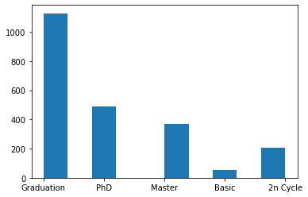

```python
plt.hist(customers["Education"])
```

```python
customers["Marital_Status"].value_counts()
```

```
Married     864
Together    580
Single      480
Divorced    232
Widow        77
Alone         3
Absurd        2
YOLO          2
Name: Marital_Status, dtype: int64
```

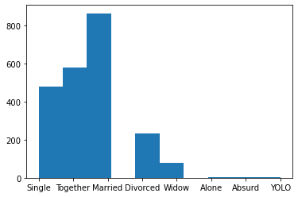

```python
plt.hist(customers["Marital_Status"])
```

Usamos dummies para transformar las variables categoricas no ordinales ya que en vez de ser 0,1,2,3 que asi les estariamos dando un rango de importancia que no queremos, por lo que ahora se diferencian con 0 y 1 donde 0 es cuando no hay y 1 cuando si.

```python
customers_numerico= pd.get_dummies(customers_numerico, columns=["Marital_Status", "Education"])
```

Por ultimo, vamos a tranformar la variable Dt Customer ya que era una fecha y lo pasamos a dias. Utilizamos una funcion que actualiza los dias a ahora cada vez que lo runeamos.

```python
from datetime import datetime
from datetime import timedelta
```

```python
customers['Dt_Customer'] = pd.to_datetime(customers['Dt_Customer'], format="%Y/%m/%d")
```

Para ver si hay alguna fecha incorrecta creamos un plot. En el observamos que las fechas van de julio de 2012 a julio de 2014 y vemos que no hay anomalias.

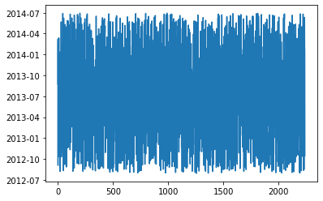

```python
customers["Dt_Customer"].plot()
```

```python
now = datetime.now()
dias=now-customers['Dt_Customer']
```

```python
customers['Days']=dias
customers_numerico['Days']=dias
```

Cambiamos los datos que estaban como Object a numerico para poder analizarlos y normalizarlos.

```python
customers_numerico= customers_numerico.apply(pd.to_numeric, errors='coerce')
```

```
2.2.- ¿Debes normalizar los datos?. Si es así, realiza la normalización.
```

```python
customers_numerico_normalizado=(customers_numerico-customers_numerico.mean())/customers_numerico.std()
```

Al normalizar los datos nos damos que Dt customer no se puede normalizar por lo que la eliminamos.

```python
customers_numerico_normalizado= customers_numerico_normalizado.drop(columns=['Dt_Customer'])
```

```
2.3.- Puede ser interesante realizar un análisis descriptivo con algún mapa de correlación y un t-sne, pca o similar para ver como se distribuyen los datos y eliminar outliers (recuerda eliminarlos también de la tabla que relaciona clientes y campañas)
```

Al realizar el analisis descriptivo de la correlacion, hemos eliminado las dummies creadas ya que sino nos salia un grafico muy aglomerado y confuso.

```python
customers_corr=customers_numerico_normalizado.drop(columns=['Marital_Status_Absurd', 'Marital_Status_Alone',
       'Marital_Status_Divorced', 'Marital_Status_Married',
       'Marital_Status_Single', 'Marital_Status_Together',
       'Marital_Status_Widow', 'Marital_Status_YOLO', 'Education_2n Cycle',
       'Education_Basic', 'Education_Graduation', 'Education_Master',
       'Education_PhD'])
```

```python
customers_corr
```

|  | Year_Birth | Income | Kidhome | Teenhome | Recency | MntWines | MntFruits | MntMeatProducts | MntFishProducts | MntSweetProducts | MntGoldProds | NumDealsPurchases | NumWebPurchases | NumCatalogPurchases | NumStorePurchases | NumWebVisitsMonth | Complain | Days |
| --- | --- | --- | --- | --- | --- | --- | --- | --- | --- | --- | --- | --- | --- | --- | --- | --- | --- | --- |
| 0 | -0.985125 | 0.235274 | -0.825033 | -0.929687 | 0.306971 | 0.983562 | 1.551231 | 1.679327 | 2.461597 | 1.476170 | 0.843019 | 0.349336 | 1.408989 | 2.510330 | -0.550662 | 0.693749 | -0.09726 | 1.530843 |
| 1 | -1.235457 | -0.235774 | 1.032328 | 0.906732 | -0.383579 | -0.870285 | -0.636159 | -0.713066 | -0.650304 | -0.631362 | -0.728843 | -0.168199 | -1.110161 | -0.568593 | -1.165865 | -0.130434 | -0.09726 | -1.190279 |
| 2 | -0.317572 | 0.773461 | -0.825033 | -0.929687 | -0.797908 | 0.362642 | 0.570677 | -0.176993 | 1.344974 | -0.146872 | -0.038757 | -0.685734 | 1.408989 | -0.226490 | 1.294948 | -0.542526 | -0.09726 | -0.205727 |
| 3 | 1.267866 | -1.022504 | 1.032328 | -0.929687 | -0.797908 | -0.870285 | -0.560732 | -0.651041 | -0.503862 | -0.582913 | -0.748012 | -0.168199 | -0.750283 | -0.910695 | -0.550662 | 0.281657 | -0.09726 | -1.061644 |
| 4 | 1.017534 | 0.241465 | 1.032328 | -0.929687 | 1.549959 | -0.388998 | 0.419822 | -0.216866 | 0.155129 | -0.001525 | -0.556322 | 1.384405 | 0.329353 | 0.115612 | 0.064541 | -0.130434 | -0.09726 | -0.952799 |
| ... | ... | ... | ... | ... | ... | ... | ... | ... | ... | ... | ... | ... | ... | ... | ... | ... | ... | ... |
| 2235 | -0.150684 | 0.358488 | -0.825033 | 0.906732 | -0.107359 | 1.203409 | 0.419822 | 0.066677 | 0.081908 | 2.202906 | 3.890897 | -0.168199 | 1.768868 | 0.115612 | -0.550662 | -0.130434 | -0.09726 | 0.135650 |
| 2236 | -1.903010 | 0.469959 | 2.889690 | 0.906732 | 0.237916 | 0.303224 | -0.661302 | -0.606738 | -0.686915 | -0.655587 | -0.690505 | 2.419475 | 1.408989 | -0.226490 | -0.243060 | 0.693749 | -0.09726 | -1.655343 |
| 2237 | 1.017534 | 0.189064 | -0.825033 | -0.929687 | 1.446377 | 1.794620 | 0.545534 | 0.221739 | -0.101145 | -0.364893 | -0.383800 | -0.685734 | -0.750283 | 0.115612 | 2.217753 | 0.281657 | -0.09726 | -0.982484 |
| 2238 | -1.068569 | 0.678884 | -0.825033 | 0.906732 | -1.419402 | 0.368584 | 0.092971 | 0.208448 | 0.777510 | 0.071149 | 0.325454 | -0.168199 | 0.689232 | 0.799817 | 1.294948 | -0.954618 | -0.09726 | -0.977537 |
| 2239 | -1.235457 | 0.024832 | 1.032328 | 0.906732 | -0.314524 | -0.653409 | -0.585874 | -0.469396 | -0.650304 | -0.631362 | -0.441307 | 0.349336 | -0.390404 | -0.568593 | -0.550662 | 0.693749 | -0.09726 | 1.327996 |

2240 rows × 18 columns

El mapa de calor nos proporciona un claro resumen visual de forma bidimensional a color de la información de nuestro dataset, donde cada color representa la correlacion entre las diferentes variables. Los colores mas intensos se atribuyen a los mas correlacionados y los mas claros a los menos correlacionados.

Visualmente destacamos la diagonal que siempre es 1 ya que es la correlacion de un valor consigo mismo, esto no nos interesa. Despues las dos variables mas correlacionadas son MntMeatProducts (cantidad gastada en carne en los dos últimos años) con NumCatalogPurchases (Número de compras a através de catálogo), con lo cual sabemos que los clientes cuando compran carne lo hacen a traves del catalogo.

Otra caracteristica a señalar, es que los clientes con un income alto hacen mucho gasto en vino, carne y compras en catalogo. En cambio vemos que no hacen uso de las ofertas.

Los clientes que hacen mayor uso de estas ofertas son aquellos con niños y adolescentes y que tienen un menor income.

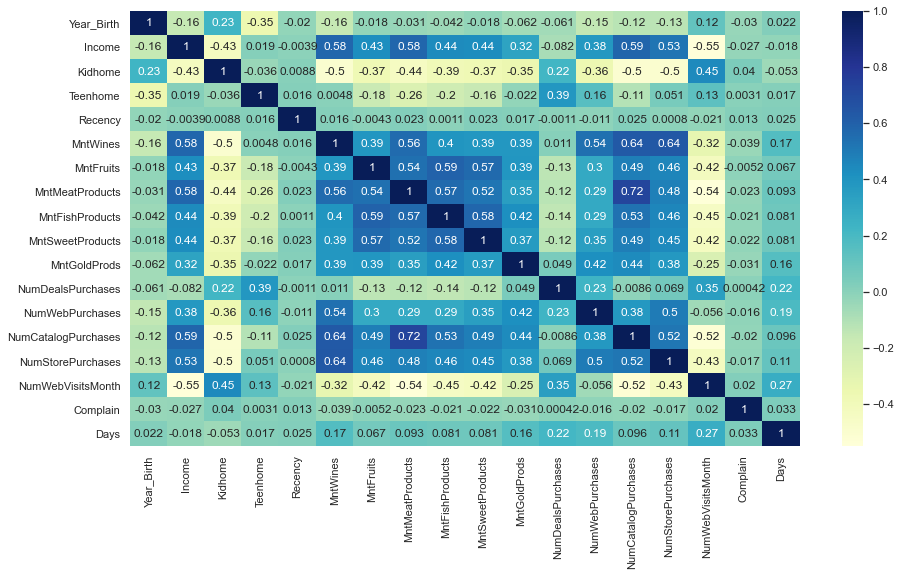

```python
sns.set(rc = {'figure.figsize':(15,8)})
dataplot = sns.heatmap(customers_corr.corr(),cmap="YlGnBu",annot=True)
```

PAra analizar la distribucion de los datos y los outliers, usaremos utilizaremos algoritmos de clusterizacion como t-SNE o DBscan y reduccion de componentes principales

Con las columnas del dataset, podemos usar t-SNE o PCA para reducirlo a dos dimensiones. PCA lo usaremos para detectar outliers y t-SNE junto a DBSCAN, para ver los datos graficamente.

##### DBSCAN

Density-based spatial clustering of applications with noise, llamado agrupamiento espacial basado en densidad de aplicaciones con ruido, es un algoritmo de data clustering que se basa en la densidad y asi encuentra el numero de clusters.

Al realizar el algorithmo necesitamos dos parámetros:

- Epsilon: Es lo cerca que deben de estar los puntos entre ellos para ser considerados parte de un clúster. Esto significa que, si la distancia es inferior o igual al épsilon, estos puntos se consideran vecinos. Para encontrar el epsilon hemos realizado un grafico de rodilla.
- Min samples: Es el numero mínimo de observaciones dentro de la región epsilon. Cuantos mas datos tengamos, mayor será el valor. Este valor es normalmente el doble de la dimension del dataframe.

```python
from sklearn.neighbors import NearestNeighbors
neigh = NearestNeighbors(n_neighbors=2)
nbrs = neigh.fit(customers_numerico_normalizado)
distances, indices = nbrs.kneighbors(customers_numerico_normalizado)
```

```python
distances = np.sort(distances, axis=0)
distances = distances[:,1]
```

```
3.5247674437941883
```

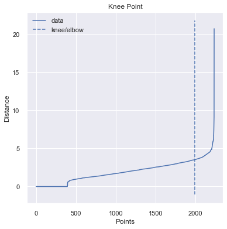

```python
from kneed import KneeLocator

i = np.arange(len(distances))
knee = KneeLocator(i, distances, S=1, curve='convex', direction='increasing', interp_method='polynomial')

fig = plt.figure(figsize=(5, 5))
knee.plot_knee()
plt.xlabel("Points")
plt.ylabel("Distance")

print(distances[knee.knee])
```

```python
customers_numerico_normalizado.ndim
```

```
2
```

Aqui hemos calculado la dimension de nuestro dataframe, es 2, por lo que el min samples sera 4, ya que es el doble de la dimension.

```python
epsilon = 3.4541262006086355
min_samples = 4

db = DBSCAN(eps=epsilon, min_samples=min_samples)
labels=db.fit_predict(customers_numerico_normalizado)
```

Representamos los datos relacionados con labels que hemos obtenido anteriormente en DBScan.

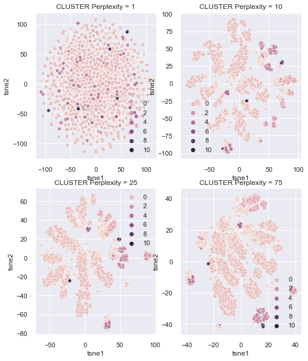

```python
plt.figure(figsize =(8,4))
plt.subplots_adjust(top=2.0)

for index, p in enumerate([1,10,25,75]):
    tsne=TSNE(n_components=2, perplexity=p, random_state=100)
    tsne_results=tsne.fit_transform(customers_numerico_normalizado)

    tsne_results=pd.DataFrame(tsne_results, columns = ['tsne1', 'tsne2'])

    plt.subplot(2,2,index+1)
    sns.scatterplot(tsne_results['tsne1'], tsne_results['tsne2'],hue=labels, s=30)
    plt.title('CLUSTER Perplexity = '+ str(p))

plt.show()
```

Obtenemos 4 graficos con una perplexidad diferente, pero eligiriamos el de la perplexidad = 25 ya que es el que mas agrupados estan.

##### T-SNE

Esto es una técnica de reducción de la dimensionalidad que se utiliza para representar un conjunto de datos de alta dimensión en un espacio de baja dimensión de dos o tres dimensiones para poder visualizarlo. A diferencia de otros algoritmos de reducción de la dimensionalidad, como el PCA, que se limita a maximizar la varianza, el t-SNE crea un espacio de características reducido en el que las muestras similares son modeladas por puntos cercanos y las muestras disímiles son modeladas por puntos distantes con alta probabilidad.

```python
tsne_customers= TSNE(n_components=2,perplexity=25,random_state=100)
data_tsne=tsne_customers.fit_transform(customers_numerico_normalizado)
```

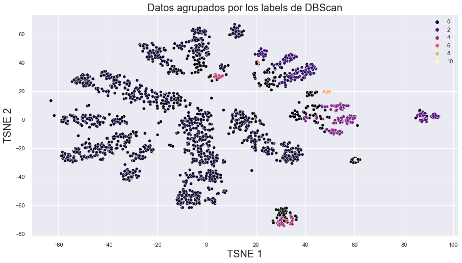

```python
sns.scatterplot(x=data_tsne[:,0],y=data_tsne[:,1],palette="magma",sizes=(50,30),hue=labels)
plt.title("Datos agrupados por los labels de DBScan", fontsize = 20)
plt.xlabel("TSNE 1", fontsize = 20)
plt.ylabel("TSNE 2", fontsize = 20)
plt.legend(loc='best')
plt.show()
```

##### PCA

Usaremos PCA para detectar outliers. Vamos a reducir los componentes, para ello haremos un train y test del dataframe de customers.

```python
trainpca,testpca = train_test_split(customers_numerico_normalizado, test_size = 0.2,random_state=10).copy()
```

```python
pca = PCA(n_components=31, random_state=100,whiten=False)
pcaNumModel = pca.fit(trainpca)
principalComponents = pcaNumModel.transform(trainpca)
```

```python
x_trans = principalComponents[:, 0]
y_trans = principalComponents[:, 1]
```

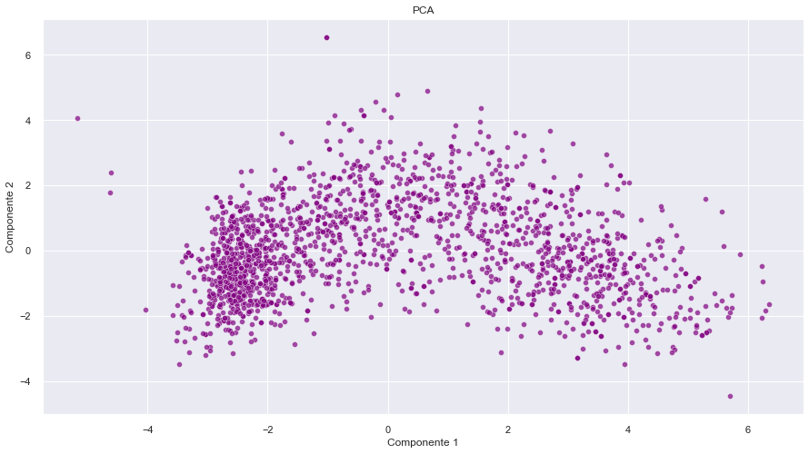

```python
sns.scatterplot(x_trans, y_trans,
               sizes=(4,4),color='purple',alpha=0.7)
plt.title('PCA')
plt.xlabel('Componente 1')
plt.ylabel('Componente 2')
```

Aunque no buscamos una reduccion dimensional, asi quedarian las dos primeras componentes reducidas.

Usamos las 31 columnas para usar todos los datos, ya que queremos detectar los outliers.

```
1.0
```

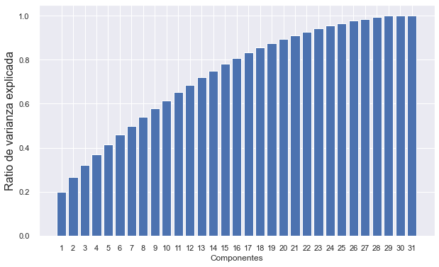

```python
print(np.sum(pcaNumModel.explained_variance_ratio_))

ev1=np.cumsum(pcaNumModel.explained_variance_ratio_)

fig, ax = plt.subplots(figsize=(10, 6))

ax.bar(np.arange(1, len(ev1) + 1, 1), ev1)
ax.set_xticks(np.arange(1, len(ev1) + 1, 1))
ax.set_xlabel('Componentes')
ax.set_ylabel('Ratio de varianza explicada', fontsize=16)
```

Aunque cogemos todas las variables, vemos que con 16 componentes ya podríamos explicar 80% de la varianza. Ahora vamos a calcular el MSE y asi poder ver los outliers representados.

```python
trainpca_numpy= trainpca.to_numpy()
train_inverse=pca.inverse_transform(principalComponents)
#MSE
mse_pca= (trainpca_numpy - train_inverse)**2

total=np.sum(mse_pca,1)

total_mean = np.mean(total)

total_std = np.std(total)

outlier= np.where(total > total_mean + 3*total_std)
```

Para poder clasificar una observacion como outlier, tiene que ser superior a la media mas tres veces la desviacion estandar.

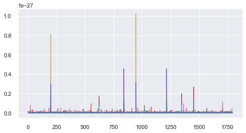

```python
plt.plot(mse_pca)
```

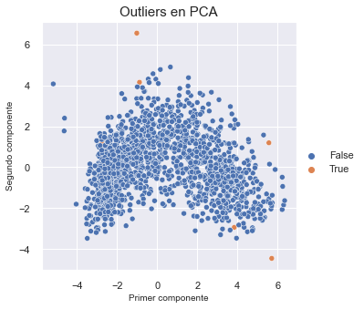

```python
mark_outlier = np.where(total > total_mean + 3*total_std, True, False)
plt.subplots(figsize=(5,5))

sns.scatterplot(x=x_trans, y=y_trans, hue= mark_outlier)
plt.xlabel("Primer componente", fontsize = 10)
plt.ylabel("Segundo componente", fontsize = 10)
plt.title("Outliers en PCA", fontsize = 15)
plt.legend(bbox_to_anchor=(1, 0.5), loc=2, borderaxespad=0.1)
sns.set(rc={"figure.figsize":(8, 4)})
plt.figure(num=None, figsize=(10, 10), dpi=80, facecolor='r', edgecolor='k')
```

Podemos observar la representacion del PCA, destacando los outliers en naranja. Estos ultimos aunque haya pocos los vamos a tratar a continuacion.

##### OUTLIERS

```python
logvero = pcaNumModel.score_samples(customers_numerico_normalizado)
mean = logvero.mean()
std = logvero.std()

print(mean-std)
print(mean+std)
logvero

# Voy a calcular los outliers restandole a la media tres veces su desviacióm

outliers = customers_numerico_normalizado.loc[logvero <= mean-3*std,]
outliers
```

```
-33.40549682778025
25.885049829394326
```

|  | Year_Birth | Income | Kidhome | Teenhome | Recency | MntWines | MntFruits | MntMeatProducts | MntFishProducts | MntSweetProducts | ... | Marital_Status_Single | Marital_Status_Together | Marital_Status_Widow | Marital_Status_YOLO | Education_2n Cycle | Education_Basic | Education_Graduation | Education_Master | Education_PhD | Days |
| --- | --- | --- | --- | --- | --- | --- | --- | --- | --- | --- | --- | --- | --- | --- | --- | --- | --- | --- | --- | --- | --- |
| 21 | 0.850646 | -1.989003e+00 | 1.032328 | -0.929687 | -0.245469 | -0.899994 | -0.636159 | 6.902720 | -0.668609 | -0.631362 | ... | -0.522116 | -0.590967 | -0.188634 | -0.029887 | -0.315613 | -0.157136 | 0.993548 | -0.444716 | -0.526267 | 0.917354 |
| 27 | 1.434754 | 8.717969e-16 | 1.032328 | -0.929687 | -1.039600 | -0.888111 | -0.636159 | -0.726357 | -0.631999 | 5.715460 | ... | 1.914427 | -0.590967 | -0.188634 | -0.029887 | -0.315613 | -0.157136 | 0.993548 | -0.444716 | -0.526267 | 0.694717 |
| 131 | -0.901681 | 3.628014e-01 | 1.032328 | 0.906732 | -0.245469 | 0.683500 | -0.535589 | -0.531421 | -0.686915 | -0.534464 | ... | -0.522116 | -0.590967 | -0.188634 | -0.029887 | -0.315613 | -0.157136 | -1.006045 | 2.247620 | -0.526267 | 0.605662 |
| 138 | 0.349981 | -6.545005e-01 | 1.032328 | 0.906732 | -0.418106 | -0.858402 | -0.661302 | -0.704205 | -0.613693 | -0.607138 | ... | -0.522116 | -0.590967 | -0.188634 | -0.029887 | -0.315613 | -0.157136 | -1.006045 | -0.444716 | 1.899327 | -1.546498 |
| 153 | 1.601643 | -7.217588e-01 | 1.032328 | -0.929687 | -1.281293 | -0.888111 | -0.485305 | -0.633320 | -0.339114 | -0.316444 | ... | -0.522116 | -0.590967 | -0.188634 | -0.029887 | -0.315613 | -0.157136 | 0.993548 | -0.444716 | -0.526267 | -1.511866 |
| 164 | 0.349981 | 4.193490e+00 | -0.825033 | 0.906732 | 1.688069 | -0.843547 | -0.611017 | 6.269179 | -0.668609 | -0.607138 | ... | -0.522116 | -0.590967 | -0.188634 | -0.029887 | -0.315613 | -0.157136 | -1.006045 | -0.444716 | 1.899327 | -1.155646 |
| 687 | 1.100978 | 4.335675e+00 | -0.825033 | -0.929687 | -0.970545 | -0.739565 | -0.259023 | 6.446393 | -0.375725 | -0.582913 | ... | -0.522116 | -0.590967 | -0.188634 | -0.029887 | -0.315613 | -0.157136 | -1.006045 | -0.444716 | 1.899327 | 1.684215 |
| 1653 | 0.683757 | 4.189616e+00 | -0.825033 | -0.929687 | -1.246765 | -0.899994 | -0.661302 | 6.902720 | -0.650304 | -0.631362 | ... | -0.522116 | 1.691387 | -0.188634 | -0.029887 | -0.315613 | -0.157136 | 0.993548 | -0.444716 | -0.526267 | 0.358287 |
| 1806 | -0.234128 | -1.801407e+00 | -0.825033 | 2.743150 | 1.480904 | -0.662322 | -0.560732 | -0.593447 | -0.595388 | -0.607138 | ... | 1.914427 | -0.590967 | -0.188634 | -0.029887 | -0.315613 | -0.157136 | -1.006045 | -0.444716 | 1.899327 | -0.740057 |
| 1898 | -1.986454 | 2.455757e+00 | -0.825033 | -0.929687 | -1.384875 | -0.885140 | -0.611017 | -0.726357 | -0.668609 | 5.691236 | ... | 1.914427 | -0.590967 | -0.188634 | -0.029887 | -0.315613 | -0.157136 | -1.006045 | -0.444716 | 1.899327 | -1.591026 |
| 1975 | 0.016205 | -1.909883e+00 | -0.825033 | 0.906732 | -1.695622 | -0.855431 | -0.560732 | -0.686484 | -0.650304 | -0.558689 | ... | -0.522116 | -0.590967 | -0.188634 | -0.029887 | -0.315613 | -0.157136 | 0.993548 | -0.444716 | -0.526267 | -0.428365 |
| 2093 | 2.018863 | 1.078240e+00 | -0.825033 | -0.929687 | 0.306971 | 0.496333 | 1.903224 | -0.185854 | 3.193810 | 0.822109 | ... | -0.522116 | -0.590967 | -0.188634 | -0.029887 | -0.315613 | -0.157136 | 0.993548 | -0.444716 | -0.526267 | 1.006409 |
| 2134 | -0.985125 | 5.287905e-01 | -0.825033 | -0.929687 | -0.038304 | -0.189947 | 1.023240 | 1.475531 | 2.955841 | -0.655587 | ... | -0.522116 | -0.590967 | -0.188634 | -0.029887 | -0.315613 | -0.157136 | -1.006045 | 2.247620 | -0.526267 | -0.908272 |
| 2177 | 0.349981 | -1.523797e-01 | -0.825033 | 0.906732 | -1.592040 | 0.053667 | -0.585874 | -0.518130 | -0.613693 | -0.582913 | ... | -0.522116 | -0.590967 | -0.188634 | 33.443990 | -0.315613 | -0.157136 | -1.006045 | -0.444716 | 1.899327 | 1.313153 |
| 2202 | 0.349981 | -1.523797e-01 | -0.825033 | 0.906732 | -1.592040 | 0.053667 | -0.585874 | -0.518130 | -0.613693 | -0.582913 | ... | -0.522116 | -0.590967 | -0.188634 | 33.443990 | -0.315613 | -0.157136 | -1.006045 | -0.444716 | 1.899327 | 1.313153 |
| 2233 | 0.683757 | 2.453965e+01 | 1.032328 | -0.929687 | -0.901490 | -0.876227 | -0.309308 | -0.659902 | -0.540472 | -0.631362 | ... | -0.522116 | 1.691387 | -0.188634 | -0.029887 | -0.315613 | -0.157136 | 0.993548 | -0.444716 | -0.526267 | 0.190072 |

16 rows × 31 columns

Despues de identificar los outliers, retiramos de nuestra tabla aquellos clientes que pertenecen a ellos. Igualmente los eliminamos de campains to customers.

```python
customers_numerico_normalizado_sin=customers_numerico_normalizado.drop(outliers.index)
```

Verificamos que hemos eliminado los outliers, para ellos vemos solo del 19 al 31. Y vemos que hemos hecho bien la limpieza ya que no aparecen los clientes 21 y 27.

```python
customers_numerico_normalizado_sin[19:30]
```

|  | Year_Birth | Income | Kidhome | Teenhome | Recency | MntWines | MntFruits | MntMeatProducts | MntFishProducts | MntSweetProducts | ... | Marital_Status_Single | Marital_Status_Together | Marital_Status_Widow | Marital_Status_YOLO | Education_2n Cycle | Education_Basic | Education_Graduation | Education_Master | Education_PhD | Days |
| --- | --- | --- | --- | --- | --- | --- | --- | --- | --- | --- | --- | --- | --- | --- | --- | --- | --- | --- | --- | --- | --- |
| 19 | 1.351310 | -0.736297 | 1.032328 | -0.929687 | 1.273740 | -0.891082 | -0.233881 | -0.655472 | -0.137756 | -0.074198 | ... | 1.914427 | -0.590967 | -0.188634 | -0.029887 | 3.167018 | -0.157136 | -1.006045 | -0.444716 | -0.526267 | 1.233993 |
| 20 | 1.100978 | -0.607372 | -0.825033 | -0.929687 | -0.279996 | -0.647467 | -0.611017 | -0.416232 | 0.576151 | 0.264945 | ... | -0.522116 | -0.590967 | -0.188634 | -0.029887 | -0.315613 | -0.157136 | 0.993548 | -0.444716 | -0.526267 | 1.664425 |
| 22 | -1.652678 | 0.254006 | -0.825033 | 0.906732 | 0.479608 | 1.672812 | -0.661302 | -0.358638 | -0.686915 | -0.655587 | ... | -0.522116 | -0.590967 | -0.188634 | -0.029887 | -0.315613 | -0.157136 | -1.006045 | -0.444716 | 1.899327 | 0.986619 |
| 23 | -1.235457 | 0.522280 | -0.825033 | 0.906732 | -1.695622 | 0.237864 | -0.661302 | -0.287752 | -0.302503 | 0.119598 | ... | -0.522116 | -0.590967 | -0.188634 | -0.029887 | -0.315613 | -0.157136 | -1.006045 | -0.444716 | 1.899327 | -0.913219 |
| 24 | -1.485789 | -0.461632 | -0.825033 | 0.906732 | 0.686773 | -0.100820 | -0.585874 | -0.620029 | 0.026992 | -0.510240 | ... | -0.522116 | 1.691387 | -0.188634 | -0.029887 | -0.315613 | -0.157136 | 0.993548 | -0.444716 | -0.526267 | 0.566082 |
| 25 | 0.016205 | -1.344298 | -0.825033 | -0.929687 | 1.377322 | -0.885140 | -0.560732 | -0.628889 | -0.412335 | -0.364893 | ... | 1.914427 | -0.590967 | -0.188634 | -0.029887 | -0.315613 | -0.157136 | 0.993548 | -0.444716 | -0.526267 | 0.937144 |
| 26 | 0.600313 | 0.044403 | 1.032328 | 0.906732 | -1.557512 | -0.388998 | -0.560732 | -0.606738 | -0.631999 | -0.510240 | ... | -0.522116 | -0.590967 | -0.188634 | -0.029887 | -0.315613 | -0.157136 | 0.993548 | -0.444716 | -0.526267 | 0.219757 |
| 28 | 1.685087 | -0.554651 | 1.032328 | -0.929687 | -0.797908 | -0.796012 | -0.611017 | -0.553573 | -0.320809 | -0.146872 | ... | -0.522116 | -0.590967 | -0.188634 | -0.029887 | -0.315613 | -0.157136 | 0.993548 | -0.444716 | -0.526267 | 0.199967 |
| 29 | -0.317572 | 1.292875 | -0.825033 | -0.929687 | 1.619014 | 1.129136 | 1.852940 | 2.809069 | -0.302503 | 0.943231 | ... | -0.522116 | -0.590967 | -0.188634 | -0.029887 | -0.315613 | -0.157136 | -1.006045 | -0.444716 | 1.899327 | -0.665844 |
| 30 | 1.685087 | -1.648238 | -0.825033 | -0.929687 | -0.521688 | -0.879198 | -0.560732 | -0.695345 | -0.650304 | -0.607138 | ... | -0.522116 | -0.590967 | -0.188634 | -0.029887 | -0.315613 | -0.157136 | -1.006045 | 2.247620 | -0.526267 | -1.561341 |
| 31 | -0.484460 | -0.544267 | -0.825033 | -0.929687 | 0.237916 | -0.570223 | -0.233881 | -0.544713 | -0.064534 | -0.122647 | ... | -0.522116 | 1.691387 | -0.188634 | -0.029887 | -0.315613 | -0.157136 | -1.006045 | 2.247620 | -0.526267 | 0.298917 |

11 rows × 31 columns

Hemos quitado los outliers de customers, y como sabemos que customers son outliers, los podemos eliminar de campaigns_to_customers.

```python
indice_outliers=[21,27,131,138,153,164,687,1653,1806,1898,1975,2093,2134,2177,2202,2233]
```

```python
campaigns_to_customers=campaigns_to_customers.set_index('customer',drop=False)
```

Retiramos los outliers haciendo que le indice coincida con el numero de los clientes.

```python
campaigns_to_customers.drop(outliers.index)
```

| customer | Unnamed: 0 | customer | campaign | result |
| --- | --- | --- | --- | --- |
| 1650 | 0 | 1650 | 34 | 1 |
| 1168 | 1 | 1168 | 85 | 0 |
| 2142 | 2 | 2142 | 36 | 0 |
| 1536 | 3 | 1536 | 12 | 0 |
| 1072 | 4 | 1072 | 74 | 0 |
| ... | ... | ... | ... | ... |
| 706 | 13435 | 706 | 13 | 0 |
| 1628 | 13436 | 1628 | 86 | 0 |
| 1142 | 13437 | 1142 | 13 | 0 |
| 1510 | 13438 | 1510 | 91 | 0 |
| 890 | 13439 | 890 | 16 | 0 |

13348 rows × 4 columns

```
2.4.- Haz un clustering haciendo uso de K-means, de la base de datos de customers. Recuerda optimizar el valor adecuado de componentes (seleccionar adecuadamente la K).
```

##### K-MEANS

Vamos a realiizar un cluster utilizando K-means. K-means es un algoritmo de clasificación no supervisada, tambien llamado clustering, que reune datos en k grupos basándose en sus características. Este agrupamiento se realiza minimizando la suma de distancias entre cada objeto y el centroide de su grupo.

```python
from sklearn.cluster import KMeans
from sklearn.metrics import pairwise_distances_argmin_min
```

Para encontrar k, realizams este grafico de codo. Obtenemos un 3, que va a ser nuestro numero de clusters.

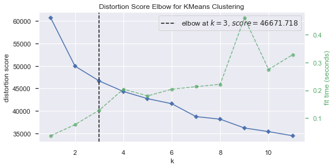

```python
from yellowbrick.cluster import KElbowVisualizer
model = KMeans()
visualizer = KElbowVisualizer(model, k=(1,12)).fit(customers_numerico_normalizado_sin)
visualizer.show()
```

Creamos una variable que crea los 3 clusters.

```python
kmeans_customers = KMeans(n_clusters=3).fit(customers_numerico_normalizado_sin)
```

Obtenemos los centroides a los que se une cada punto.

```python
centroids_customers = kmeans_customers.cluster_centers_
print(centroids_customers)
```

```
[[-4.68453039e-02  9.13216513e-01 -7.54703038e-01 -5.94643167e-01
   2.17180190e-02  8.61764632e-01  1.11234192e+00  1.23671854e+00
   1.16365377e+00  1.08040614e+00  6.46346245e-01 -5.52118691e-01
   4.03063356e-01  1.07832757e+00  8.36986794e-01 -1.02696407e+00
  -2.58355456e-02 -2.98873903e-02 -3.66126086e-02 -3.48727373e-02
  -6.75215188e-02  8.17772651e-02  1.00663206e-02  4.74905683e-02
  -2.98873903e-02  2.60560478e-02 -1.45916721e-01  1.36579314e-01
  -7.39987153e-02 -6.28577472e-02 -5.72453205e-04]
 [ 2.61394197e-01 -7.03705107e-01  6.68610315e-01 -1.44736600e-01
   1.91503430e-02 -7.89745780e-01 -5.38738515e-01 -6.39621766e-01
  -5.53846384e-01 -5.31502303e-01 -5.50624276e-01 -1.67684337e-01
  -7.28103397e-01 -7.29782100e-01 -8.11481101e-01  4.77052559e-01
   3.68028035e-02 -2.98873903e-02 -3.66126086e-02 -2.01984615e-02
   1.98334315e-03  6.64323035e-02 -1.69750488e-02 -6.31734928e-02
  -2.98873903e-02  7.90385986e-02  1.86269603e-01 -3.20883923e-02
  -1.11591282e-02 -7.53864794e-02 -1.61588491e-01]
 [-3.79008760e-01  2.24561753e-01 -3.64337751e-01  7.71234446e-01
  -3.56479449e-02  4.74095174e-01 -1.56242986e-01 -1.51627800e-01
  -1.83274569e-01 -1.53412928e-01  2.54044487e-01  7.38502551e-01
   7.39513274e-01  1.23668102e-01  5.42603588e-01  2.06613876e-01
  -3.21146140e-02 -2.98873903e-02 -3.66126086e-02  7.22418147e-02
   6.54548110e-02 -1.77863823e-01  2.53047496e-02  6.11909871e-02
  -2.98873903e-02 -1.40661818e-01 -1.57135691e-01 -7.05998223e-02
   8.78337905e-02  1.62951754e-01  2.55399254e-01]]
```

Creamos una varible recogiendo cada etiqueta de cluster para poder usarla en el ejercicio 4.

```python
labels_customers=kmeans_customers.labels_
```

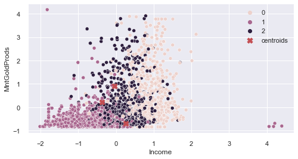

```python
sns.scatterplot(data=customers_numerico_normalizado_sin, x="Income", y="MntGoldProds", hue=kmeans_customers.labels_)
plt.scatter(kmeans_customers.cluster_centers_[:,0], kmeans_customers.cluster_centers_[:,1],
            marker="X", c="r", s=80, label="centroids")
plt.legend()
plt.show()
```

Representamos nuestros 3 grupos con sus centroides comparando Income con productos "Gourmet", ya que esta relacion nos parece interesante.

Observamos unos puntos dispersos perteneciendo al cluster 1, esto de puede tratar de outliers o de errores.

##### 3.- Realiza las acciones adecuadas sobre campaigns.csv:

```
3.1 Transformación del dataset si es necesario.
3.2 Normaliza si es necesario.
3.3 Quizá sea interesante un pequeño análisis descriptivo.
3.4 Haz un clustering haciendo uso de K-means, de la base de datos de customers. Recuerda optimizar el valor adecuado de componentes.
```

Transformamos el dataset, para ello empezamos haciendo una limpieza de los datos que nos parecen innecesarios. Eliminamos la columna de id y la del nombre. Normalizamos porque vamos a hacer un mapa de correlacion y un K-means mas adelante.

```python
campaigns_numerico=campaigns.drop(columns=['campaign_id', 'name'])
```

```python
campaigns_numerico_normalizado=(campaigns_numerico-campaigns_numerico.mean())/campaigns_numerico.std()
```

[figure not shown]

```python
sns.set(rc = {'figure.figsize':(15,8)})
dataplot = sns.heatmap(campaigns_numerico_normalizado.corr(),cmap="YlGnBu",annot=True)
```

En este mapa de corrrelacion, observamos una alta correlacion entre las campañas de comida y los dias de duracion, por lo que las campañas de comida tienen mas duracion que las de bebida, que estan negativamente correlacionadas. Hay una correlacion alta entre el descuento y las campañas lo que no deberiamos de tener en cuento ya que no tiene sentido.

Analizamos la relacion que tienen las probabilidades de comida y las de bebida. Realizamos dos grficos de la relacion de precio con comida y bebida.

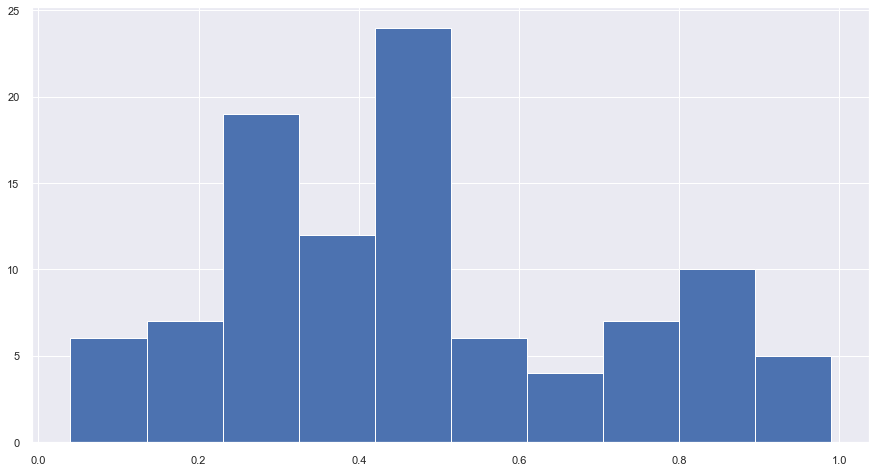

```python
plt.hist(campaigns["prob_drink"])
```

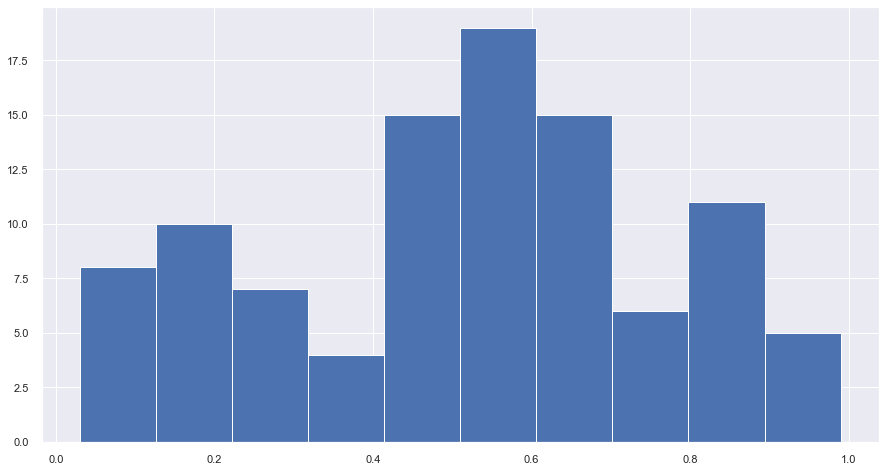

```python
plt.hist(campaigns["prob_food"])
```

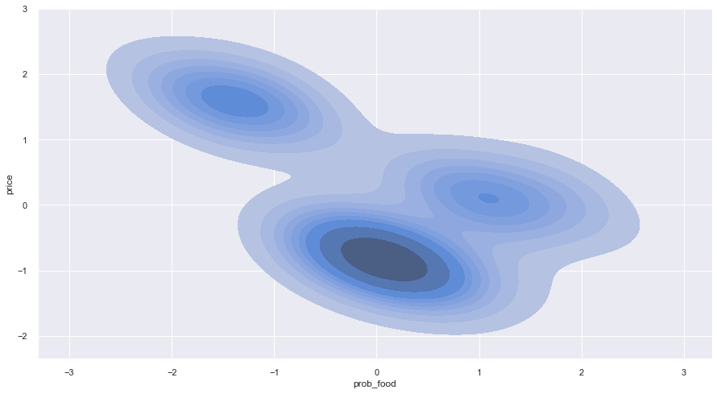

```python
import io
import requests
sns.kdeplot(campaigns_numerico_normalizado['prob_food'],campaigns_numerico_normalizado['price'],shade=True)
```

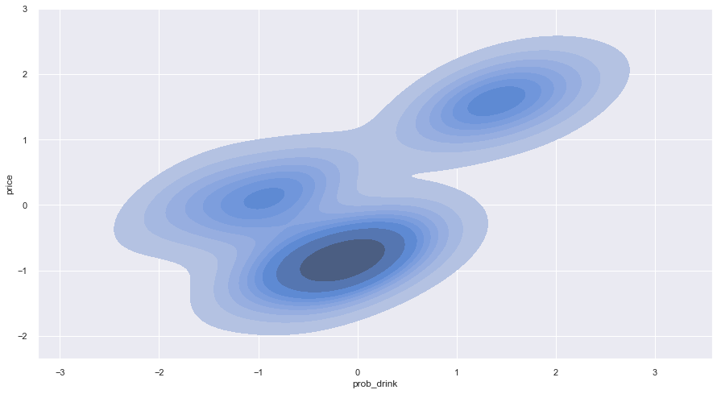

```python
sns.kdeplot(campaigns_numerico_normalizado['prob_drink'],campaigns_numerico_normalizado['price'],shade=True)
```

##### KMEANS

Volvemos a realizar un K-means, donde tambien obtenemos que el numero de clusters es 3 gracias al grafico de codo.

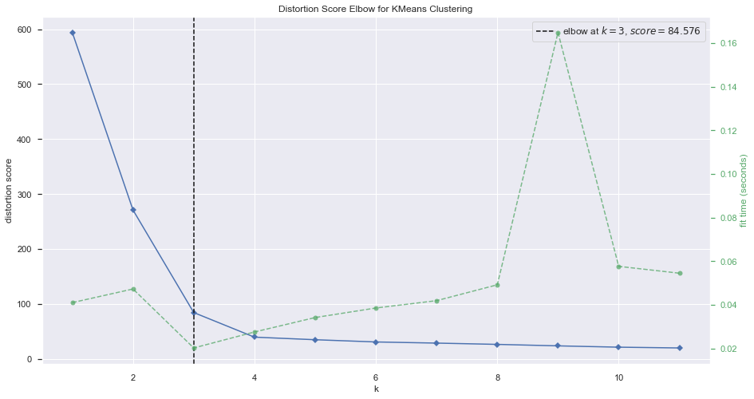

```python
model_campaigns = KMeans()
visualizer_campaigns = KElbowVisualizer(model, k=(1,12)).fit(campaigns_numerico_normalizado)
visualizer_campaigns.show()
```

```python
kmeans_campaigns = KMeans(n_clusters=3).fit(campaigns_numerico_normalizado)
```

```python
centroids_campaigns = kmeans_campaigns.cluster_centers_
print(centroids_campaigns)
```

```
[[ 7.14727100e-01 -6.79219969e-01  9.48249901e-01 -4.02779915e-01
  -6.52762754e-01 -2.31111593e-33]
 [-1.37879802e+00  1.44556280e+00 -1.06848908e+00  1.58178807e+00
  -2.72616471e-01 -1.40712473e+00]
 [-5.06561843e-02 -8.71228603e-02 -8.28010720e-01 -7.76228241e-01
   1.57814198e+00  1.40712473e+00]]
```

Creamos de nuevo una variable donde almacenar las labels, para su uso mas adelante.

```python
labels_campaigns=kmeans_campaigns.labels_
```

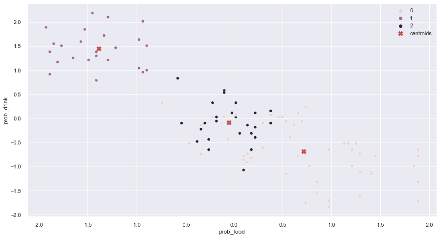

```python
sns.scatterplot(data=campaigns_numerico_normalizado, x="prob_food", y="prob_drink", hue=kmeans_campaigns.labels_)
plt.scatter(kmeans_campaigns.cluster_centers_[:,0], kmeans_campaigns.cluster_centers_[:,1],
            marker="X", c="r", s=80, label="centroids")
plt.legend()
plt.show()
```

##### 4.- Haciendo uso del dataset de entrenamiento de campaigns_to_customers_launched.csv, calcula el valor esperado de éxito para clúster de campañas mostrado a cada clúster de clientes. Este valor esperado, podría representar, de forma aproximada, por cada combinación de clusters campaña-cliente, la probabilidad de éxito al ofrecer una campaña al azar de un clúster de campañas a un cliente al azar de un clúster de clientes.

Para este ejercicio, creamos unos nuevos dataframes desde los originales. Creamos como nuevas columnas las labels hayadas anteriormente en K-means. Dejamos solo las colunmas que nos interesan que van a ser el id para poder juntarlas luego con la tabla de campaigns to customers...

```python
customers_ej4=customers
campaigns_ej4=campaigns
```

```python
customers_ej4=customers_ej4.drop(outliers.index)
```

```python
customers_ej4['labels_customers']=labels_customers

campaigns_ej4["labels_campaigns"]=labels_campaigns
```

```python
customers_ej4= customers_ej4.drop(columns=['Year_Birth','Education',
                                           'Marital_Status','Income','Kidhome', 'Teenhome', 'Dt_Customer',
                                          'Recency', 'MntWines', 'MntFruits','MntMeatProducts',
                                           'MntFishProducts', 'MntSweetProducts', 'MntGoldProds',
                                           'NumDealsPurchases', 'NumWebPurchases','NumCatalogPurchases',
                                          'NumStorePurchases', 'NumWebVisitsMonth', 'Complain','Z_CostContact',
                                           'Z_Revenue', 'Response', 'Days'])
```

```python
campaigns_ej4=campaigns_ej4.drop(columns=['prob_food','prob_drink','outdate','price','discount', 'name' ])
```

El objetivo de este ejercicio es obtener una tabla que para cluster de cliente nos indique como de exitosa ha sido la campaña, estas campañas estando igualmente agrupada rn clusters. Para ello utilizaremos las funciones de merge, juntando las colunmas de id que coinciden con con las de clientes y campañas en customers to campaigns.

```python
a=train.merge(customers_ej4,  left_on='customer', right_on='customer_id')
b=a.merge(campaigns_ej4,left_on='campaign', right_on='campaign_id' )
```

Queremos medir la probabilidad de exito, para ello creamos una columna que sean todo unos, que os servira como denominador a la hora de calcular la probabilidad. Por ejemplo si para campañas tenemos 4 filas pero solo 1 exitosa entonces solo 25% sera axitoso.

```python
b["uno"]=1
```

```python
b
```

|  | Unnamed: 0 | customer | campaign | result | customer_id | labels_customers | campaign_id | labels_campaigns | uno |
| --- | --- | --- | --- | --- | --- | --- | --- | --- | --- |
| 0 | 12130 | 170 | 65 | 0 | 170 | 1 | 65 | 2 | 1 |
| 1 | 3099 | 2167 | 65 | 1 | 2167 | 0 | 65 | 2 | 1 |
| 2 | 3769 | 2212 | 65 | 0 | 2212 | 1 | 65 | 2 | 1 |
| 3 | 4303 | 1635 | 65 | 0 | 1635 | 2 | 65 | 2 | 1 |
| 4 | 9543 | 730 | 65 | 0 | 730 | 1 | 65 | 2 | 1 |
| ... | ... | ... | ... | ... | ... | ... | ... | ... | ... |
| 8005 | 9968 | 429 | 26 | 0 | 429 | 0 | 26 | 1 | 1 |
| 8006 | 8356 | 1847 | 26 | 0 | 1847 | 1 | 26 | 1 | 1 |
| 8007 | 4112 | 1748 | 26 | 0 | 1748 | 2 | 26 | 1 | 1 |
| 8008 | 9224 | 2069 | 26 | 0 | 2069 | 1 | 26 | 1 | 1 |
| 8009 | 12232 | 1153 | 26 | 0 | 1153 | 0 | 26 | 1 | 1 |

8010 rows × 9 columns

```python
exito_campañas_train=b.groupby(["labels_customers","labels_campaigns"]).sum().reset_index()
```

```python
exito_campañas_train["exito"]=(exito_campañas_train.result/exito_campañas_train.uno)*100
```

```python
exito_campañas_train
```

|  | labels_customers | labels_campaigns | Unnamed: 0 | customer | campaign | result | customer_id | campaign_id | uno | exito |
| --- | --- | --- | --- | --- | --- | --- | --- | --- | --- | --- |
| 0 | 0 | 0 | 6941281 | 1183208 | 58639 | 286 | 1183208 | 58639 | 1039 | 27.526468 |
| 1 | 0 | 1 | 3682700 | 617001 | 24091 | 96 | 617001 | 24091 | 540 | 17.777778 |
| 2 | 0 | 2 | 3211505 | 546129 | 20976 | 105 | 546129 | 20976 | 473 | 22.198732 |
| 3 | 1 | 0 | 12042237 | 2038581 | 100262 | 555 | 2038581 | 100262 | 1810 | 30.662983 |
| 4 | 1 | 1 | 6115579 | 1048570 | 40262 | 149 | 1048570 | 40262 | 914 | 16.301969 |
| 5 | 1 | 2 | 6121949 | 1062061 | 39079 | 228 | 1062061 | 39079 | 932 | 24.463519 |
| 6 | 2 | 0 | 7744114 | 1191081 | 63684 | 352 | 1191081 | 63684 | 1128 | 31.205674 |
| 7 | 2 | 1 | 4127316 | 653874 | 27677 | 78 | 653874 | 27677 | 614 | 12.703583 |
| 8 | 2 | 2 | 3745926 | 602830 | 24058 | 161 | 602830 | 24058 | 560 | 28.750000 |

```python
exito_campañas_train=exito_campañas_train.drop(columns=['Unnamed: 0','customer','campaign','customer_id','campaign_id', 'uno','result'])
```

```python
exito_campañas_train
```

|  | labels_customers | labels_campaigns | exito |
| --- | --- | --- | --- |
| 0 | 0 | 0 | 27.526468 |
| 1 | 0 | 1 | 17.777778 |
| 2 | 0 | 2 | 22.198732 |
| 3 | 1 | 0 | 30.662983 |
| 4 | 1 | 1 | 16.301969 |
| 5 | 1 | 2 | 24.463519 |
| 6 | 2 | 0 | 31.205674 |
| 7 | 2 | 1 | 12.703583 |
| 8 | 2 | 2 | 28.750000 |

Obtenemos nuestra tabla, en la primera columna tenemos los cluesters de customers que estan agrupados primero los 0, luego los 1 y por ultimo los 2. Despues tenemos campains donde estan los clusters que estan dentro de customers y sus probabilidades de exito. Esta ultima es el calculo de agrupar clientes y campañas y dividirlo por el total de las campañas.

```python
#histo= exito_campañas_train.groupby("labels_customers")
```

Por ultimo en este ejercicio hemos creado una tabla para observar la distribucion de los clientes en los clusters y otra para ver la distribucion de las campañas en los clusters.

```python
z=customers_ej4.groupby("labels_customers").count()
z.head()
```

| labels_customers | customer_id |
| --- | --- |
| 0 | 581 |
| 1 | 1006 |
| 2 | 637 |

```python
zz=campaigns_ej4.groupby("labels_campaigns").count()
zz.head()
```

| labels_campaigns | campaign_id |
| --- | --- |
| 0 | 50 |
| 1 | 25 |
| 2 | 25 |